# Mission 1 — Titanic: modéliser la survie (logistique)

```r
source("../../utils/requirements.R")
library(titanic); library(dplyr); library(broom); library(ggplot2); library(janitor)
data("titanic_train")
df <- titanic_train %>%
  clean_names() %>%
  mutate(
    survived = factor(survived, levels=c(0,1), labels=c("No","Yes")),
    sex = factor(sex),
    pclass = factor(pclass),
    embarked = factor(embarked)
  ) %>%
  select(survived, pclass, sex, age, sib_sp, parch, fare, embarked)
set.seed(123)
```

## Objectifs

- EDA rapide — comprendre les prédicteurs clés et le **sens attendu** des effets
- Modèle de **régression logistique** `glm(..., family = binomial)`
- Interprétation des coefficients via **odds ratios** (rapports de cotes)
- Évaluation de base : **prédictions**, **matrice de confusion** (seuil 0.5), **sensibilité/spécificité**
- Préparer le terrain pour M2 (ROC, AUC, **choix de seuil**)

### 1) EDA éclair

```r
summary(df)
```

```
 survived  pclass      sex           age            sib_sp
 No :549   1:216   female:314   Min.   : 0.42   Min.   :0.000
 Yes:342   2:184   male  :577   1st Qu.:20.12   1st Qu.:0.000
           3:491                Median :28.00   Median :0.000
                                Mean   :29.70   Mean   :0.523
                                3rd Qu.:38.00   3rd Qu.:1.000
                                Max.   :80.00   Max.   :8.000
                                NA's   :177
     parch             fare        embarked
 Min.   :0.0000   Min.   :  0.00    :  2
 1st Qu.:0.0000   1st Qu.:  7.91   C:168
 Median :0.0000   Median : 14.45   Q: 77
 Mean   :0.3816   Mean   : 32.20   S:644
 3rd Qu.:0.0000   3rd Qu.: 31.00
 Max.   :6.0000   Max.   :512.33
```

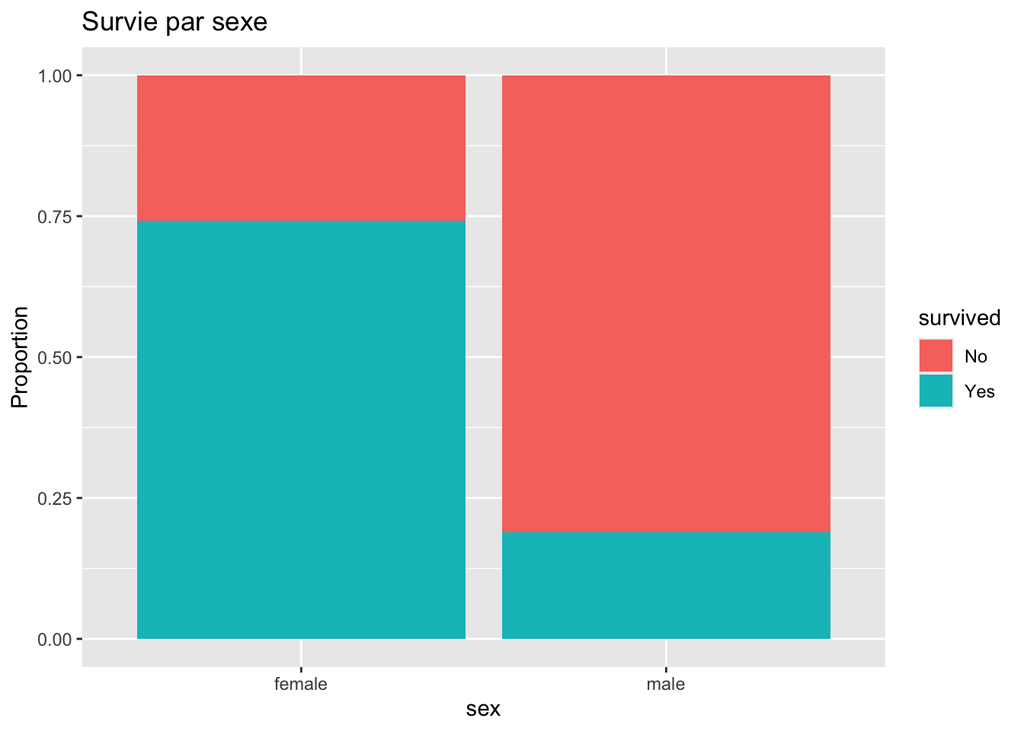

```r
ggplot(df, aes(sex, fill=survived)) + geom_bar(position="fill") + labs(y="Proportion", title="Survie par sexe")
```

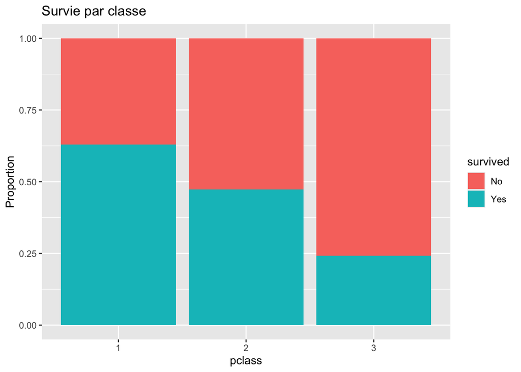

```r
ggplot(df, aes(pclass, fill=survived)) + geom_bar(position="fill") + labs(y="Proportion", title="Survie par classe")
```

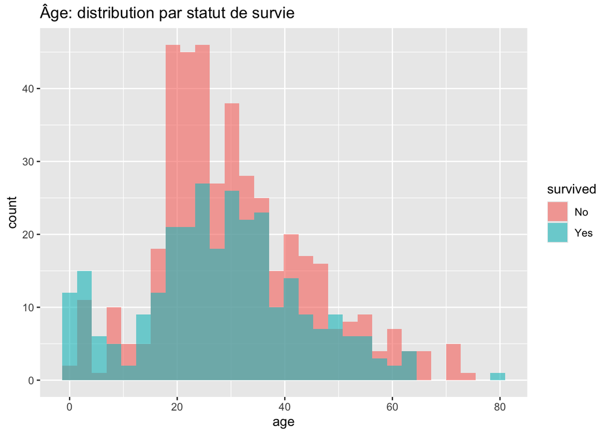

```r
ggplot(df, aes(age, fill=survived)) + geom_histogram(alpha=.6, bins=30, position="identity") + labs(title="Âge: distribution par statut de survie")
```

**Note**

**À faire (équipe)**  
- Quelles variables semblent **fortement associées** à la survie ?  
- Y a-t-il des **valeurs manquantes** importantes (ex. *age*) ? Comment les géreriez-vous pour un premier modèle simple (supprimer lignes manquantes vs imputation grossière) ?

> Astuce : pour aller vite, on peut **filtrer** les `NA` dans un premier temps, puis discuter des alternatives plus rigoureuses plus tard.

```r
df_complete <- df %>% tidyr::drop_na()
```